# Grundlagen der Resilienz

Cyber Security Management · Termin 1

Prof. Dr. Dirk Loomans

Hochschule Mainz · dirk.loomans@hs-mainz.de

## About …

**Prof. Dr. Dirk Loomans**, Diplom-Physiker

- Studium Physik und Informatik (Bayreuth), Promotion in theoretischer Polymerphysik (Freiburg).
- ehem. Partner Cyber Security and Resilience bei KPMG, CEO Loomans & Matz, CISO Infineon
- Hochschule Mainz, Fachbereich Wirtschaft: Wirtschaftsinformatik, insbesondere Cyber Security und Softwareentwicklung (WiSe 2011/12 – SoSe 2015 und seit SoSe 2025)
- Lehre: Projektmanagement, Cyber-Resilienz, IT-Security, Digital Business
- Forschung: KI und Cyber, Digitale Souveränität
- Fun Fact: Hobbybrauer und Fastnachts-Aficionado

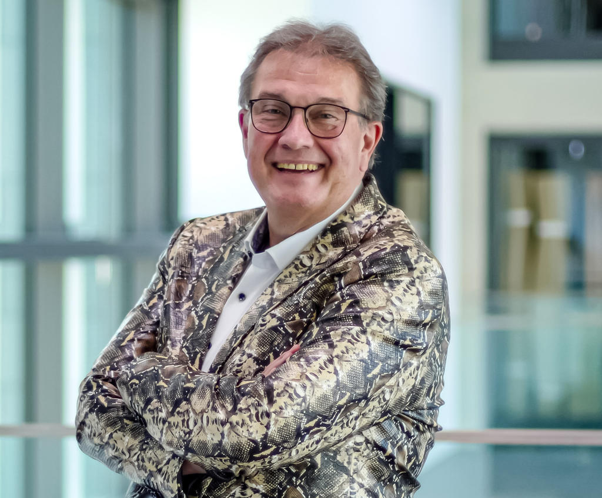

## Zugang zum Kurs in OLAT

Kursunterlagen, Skripte und Ankündigungen liegen in OLAT.

Zugangskennwort: CSMWS26ECR

## Semesterüberblick

1. **Grundlagen der Resilienz: Safety & Security** ← heute
2. Modelle und Messbarkeit
3. Resilienz-Architekturen
4. Cyber-Bedrohungen und Resilienzstrategien
5. Resilienz als Organisationsfähigkeit
6. Rollen und Verantwortlichkeiten
7. Technische Resilienz I: Backup, DR, Notfalltests
8. Technische Resilienz II: Zero Trust, Microsegmentation, Cloud, Netz
9. Sonderthemen OT und KI · 10. Resilienz der Zukunft · 11. Klausur

## Agenda

- Einleitung & Lernziele
- Begriff und Herkunft der Resilienz
- Safety vs. Security
- Physikalisch-systemische Perspektive
- Technische Resilienzprinzipien
- Standards und Regulierung
- Fallstudien & Übung
- Zusammenfassung & Ausblick

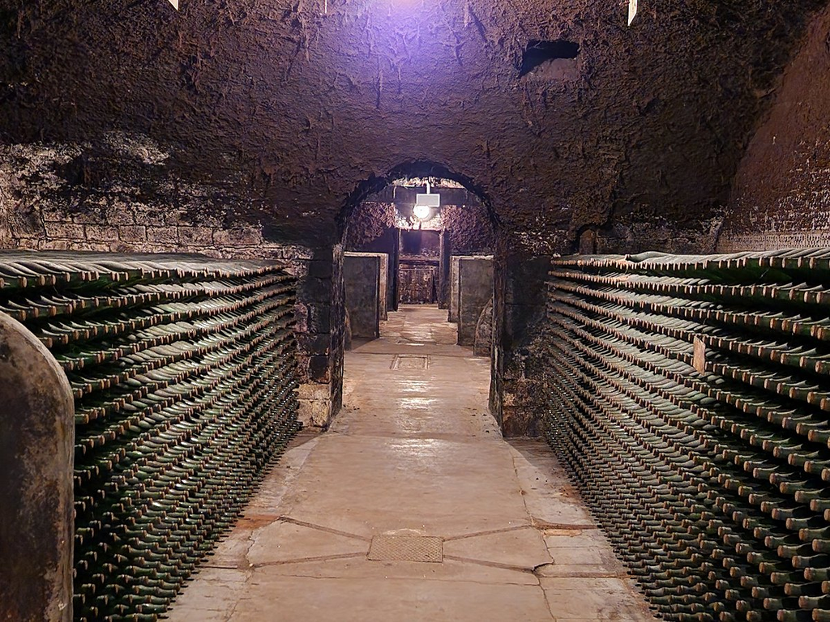

Flaschenlager Kupferberg, Mainz

## Lernziele

Nach dieser Sitzung können Sie …

- den Begriff **Resilienz** definieren und von Robustheit, Zuverlässigkeit und Sicherheit abgrenzen,
- den Unterschied zwischen **Safety** und **Security** erläutern,
- technische und organisatorische **Resilienzprinzipien** benennen und anwenden,
- Resilienz in **Cyber-Security-Management, Business Continuity und Incident Response** einordnen.

## Warum Resilienz wichtig ist

IT-Systeme sind nie vollkommen sicher.

Angriffe, Ausfälle und Fehlbedienungen sind unvermeidlich.

**Entscheidend ist: Wie schnell können wir uns erholen und weiterarbeiten?**

Diskussionsfrage: Wie lange darf euer Lieblingsspiel down sein?

## Ausfälle sind normal: 19. Juli 2024

- Ein fehlerhaftes Update einer **Sicherheitssoftware** (CrowdStrike Falcon)
- Rund 8,5 Mio. Windows-Rechner bleiben im Bluescreen hängen – Flughäfen, Kliniken, Banken, Sender
- Kein Angriff – und trotzdem ein massiver Sicherheitsvorfall
- Wiederherstellung oft nur manuell, Rechner für Rechner

[figure not shown]

## Was bedeutet Resilienz?

- Resilienz = Widerstands- und Anpassungsfähigkeit bei Störungen.
- Herkunft: Physik, Psychologie, Systemtheorie – heute technische und organisatorische Systeme.
- In der IT: Systeme bleiben trotz Störungen funktionsfähig oder erholen sich schnell.

[figure not shown]

## Resilienz ist nicht dasselbe wie …

| Begriff | Leitfrage | Bild |
| --- | --- | --- |
| **Robustheit** | Hält das System der Störung stand, ohne nachzugeben? | Fels |
| **Zuverlässigkeit** | Funktioniert es unter Normalbedingungen dauerhaft? | Uhrwerk |
| **Sicherheit** | Ist es vor Schäden und Angriffen geschützt? | Tresor |
| **Resilienz** | Bleibt es funktionsfähig, erholt es sich – und lernt es? | Bambus im Sturm |

## Woher kommt der Begriff?

- **Materialwissenschaft** (19. Jh.): Rückfederung nach Verformung
- **Psychologie**: Emmy Werner, Kauai-Längsschnittstudie (ab 1955)
- **Ökologie**: C. S. Holling (1973) – Ökosysteme absorbieren Störungen
- **Resilience Engineering**: Hollnagel, Woods & Leveson (2006)
- **Cyber**: NIST SP 800-160 Vol. 2 (2019, Rev. 1 2021)

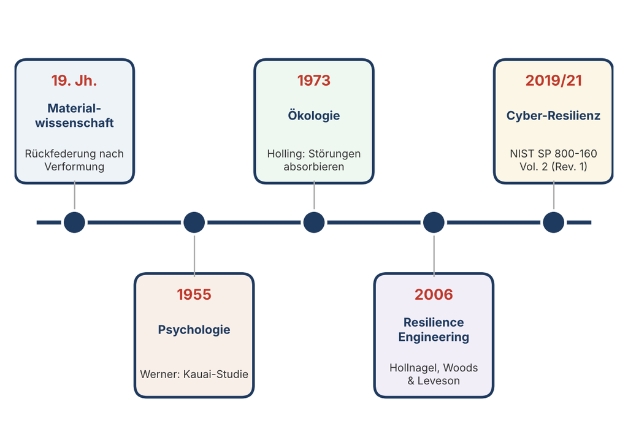

## Resilience Engineering: vier Fähigkeiten

- **Anticipate** – Was könnte passieren?
- **Monitor** – Worauf müssen wir achten?
- **Respond** – Was tun wir jetzt?
- **Learn** – Was lernen wir daraus?

Resilienz ist etwas, das ein System **tut** – nicht etwas, das es **hat**.

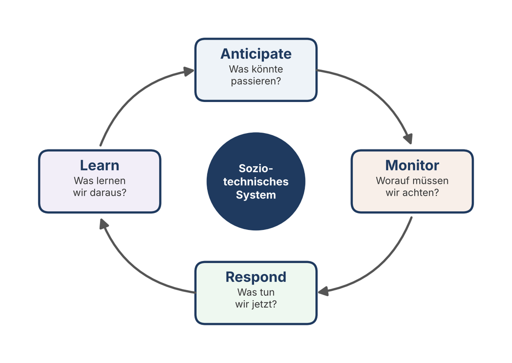

## Die Resilienzkurve

- Störung → Leistungsabfall → degradierter Betrieb → Wiederherstellung → Anpassung
- NIST-Ziele: **Anticipate, Withstand, Recover, Adapt**
- Die Fläche „fehlender Leistung“ ist der Schaden
- Resilienz heißt: Abfall flacher, Erholung schneller, danach besser

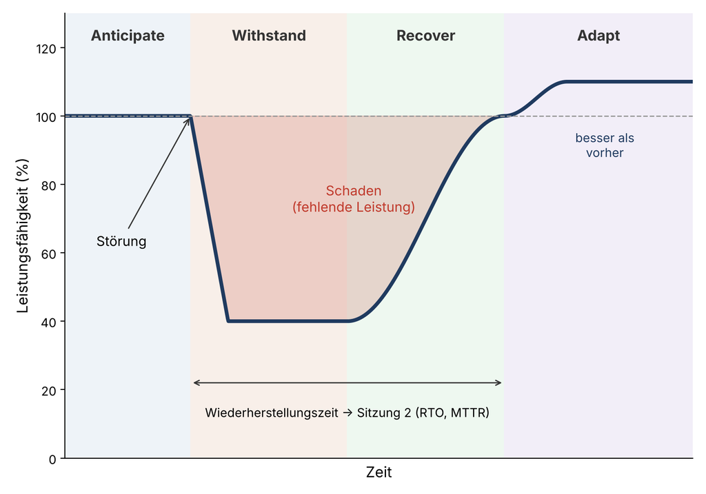

## Safety vs. Security – der Unterschied

**Safety:** Schutz vor unbeabsichtigten Fehlern und Unfällen – Hardwaredefekt, Stromausfall, Brand.

**Security:** Schutz vor absichtlichen Angriffen – Ransomware, Social Engineering, Hacking.

Beide beeinflussen die Resilienz eines Systems.

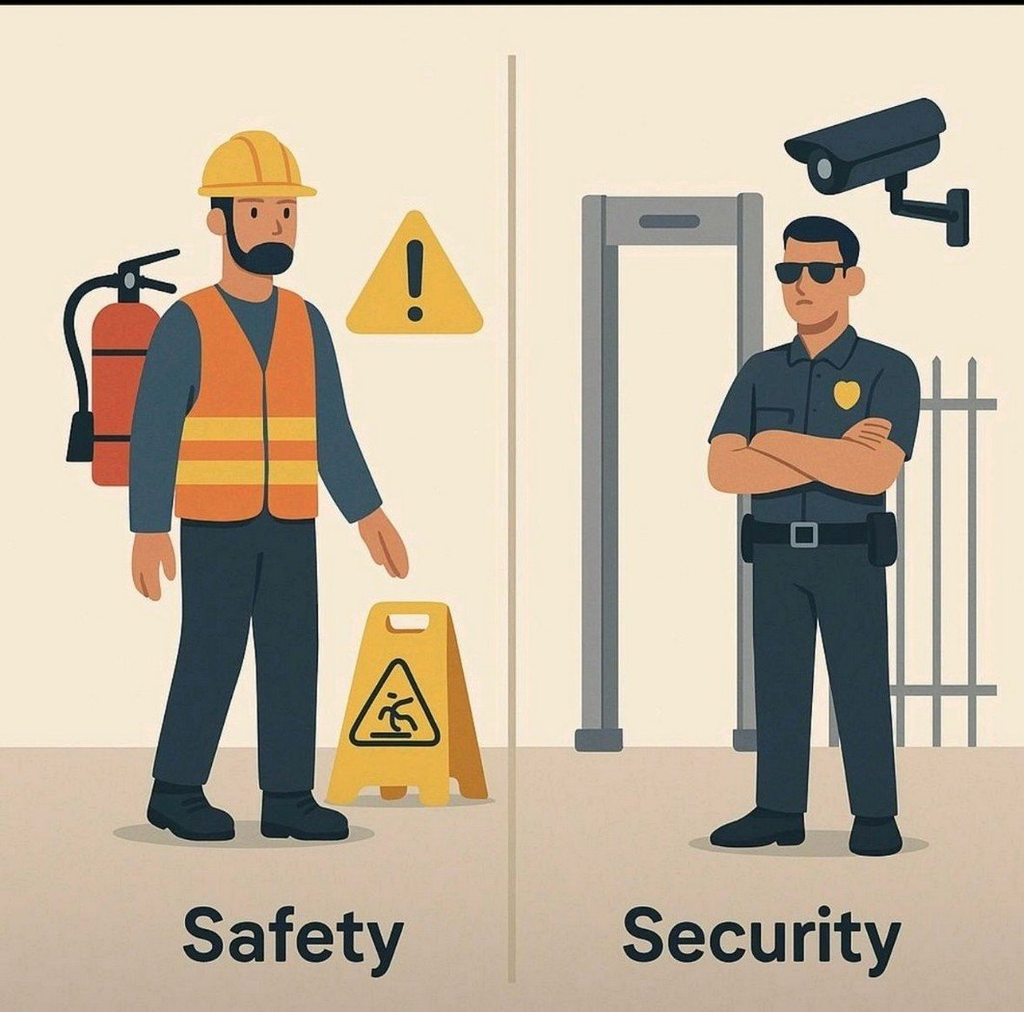

## Wo Safety und Security sich treffen

- **Security → Safety:** Stuxnet (2010) – Schadcode zerstört Uranzentrifugen physisch
- **Security → Versorgung:** Colonial Pipeline (2021) – Ransomware in der IT, Pipeline (OT) vorsorglich abgeschaltet, Treibstoffengpässe an der US-Ostküste
- **Safety → Security:** Notbetrieb und Fail-open öffnen Angriffsflächen
- Frage: Wo kippt es bei Smart Home, Auto, Cloud-Gaming?

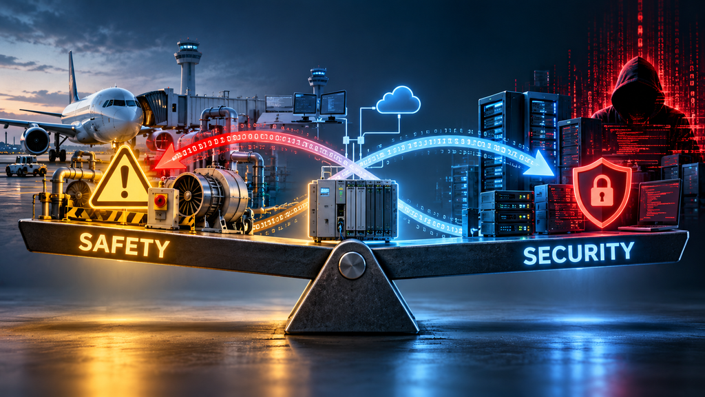

## Resilienz verbindet beides

Ziel: nicht Unverwundbarkeit, sondern Reaktions- und Wiederherstellungsfähigkeit.

**Safety + Security + Adaptivität = Resilienz**

Fokus: robust designen, Störungen erkennen, reagieren, wiederherstellen.

[figure not shown]

## Physikalische Perspektive (Analogie)

- Pendel / Schwingkreis: Störung → Auslenkung → Rückkehr zur Balance.
- Elastizität vs. Fragilität: Gummi vs. Glas.
- Übertragung auf IT-Systeme und Organisationen: Monitoring, Alerting und Autoscaling wirken wie Regelkreise.

[figure not shown]

## Der Regelkreis im IT-Betrieb

| Regelungstechnik | IT-Betrieb |
| --- | --- |
| Sollwert | Service Level Objective (SLO) |
| Sensor | Monitoring: Metriken, Logs |
| Regler | Alerting, Runbooks, SOAR |
| Stellglied | Autoscaling, Failover, Isolation |

Falsch gedämpft schwingt auch die IT: zu aggressives Autoscaling oszilliert.

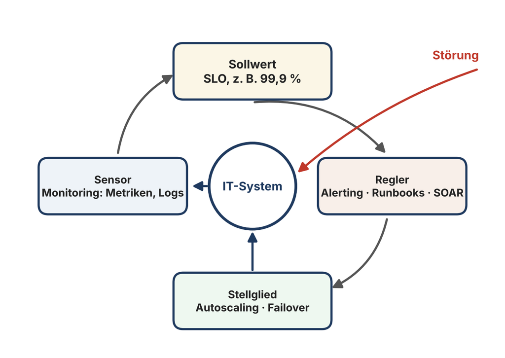

## Technische Resilienzprinzipien

- **Redundanz** – mehrere Wege und Komponenten
- **Diversität** – heterogene Komponenten reduzieren Kaskadenfehler
- **Wiederherstellbarkeit** – Backups, DR-Prozesse, Automatisierung
- **Adaptivität** – Skalierung, Umschalten, Lernen

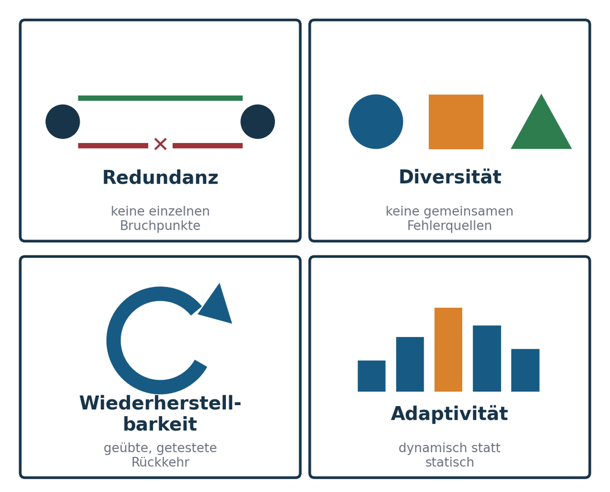

## Redundanz ohne Diversität: Ariane 5

- Flug 501 (1996): zwei redundante Trägheitsnavigationssysteme
- Identische Software → identischer Fehler (Zahlenüberlauf), beide fallen kurz nacheinander aus
- Rakete zerstört sich nach ca. 37 Sekunden
- Redundanz schützt vor **zufälligen** Fehlern, nicht vor **gemeinsamen Ursachen** (Common Mode Failure)

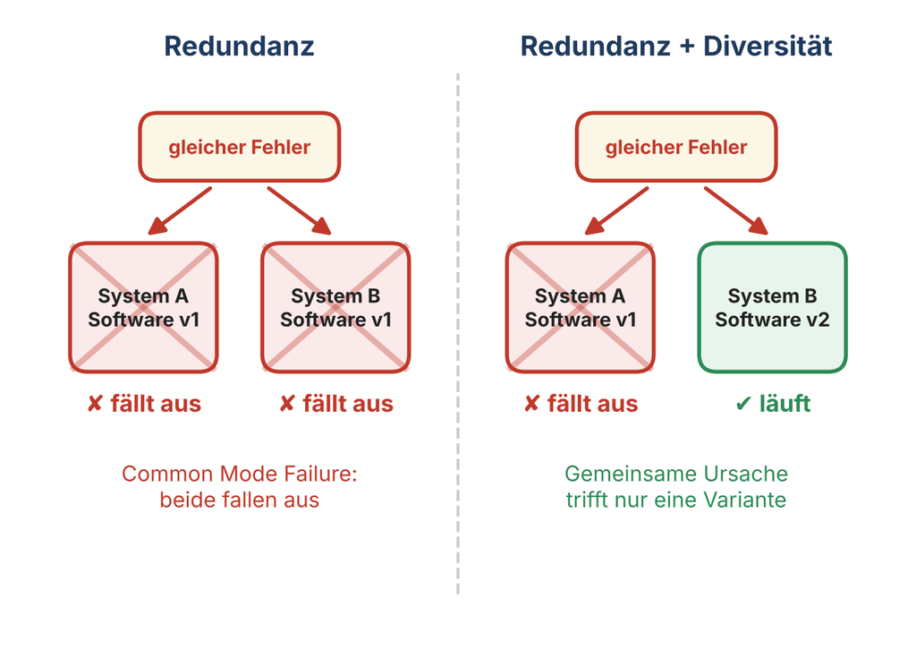

## Wiederherstellbarkeit: Das Kupferberg-Problem

- 1960: Kupferberg stellt auf Edelstahltanks um – das Flaschenlager bleibt als **Fallback**
- Heute weiß niemand mehr, welche Flaschen noch voll sind
- Bewegen? Flaschen könnten platzen – Kettenreaktion

**Ein Backup, das nie getestet wurde, ist eine Hoffnung.**

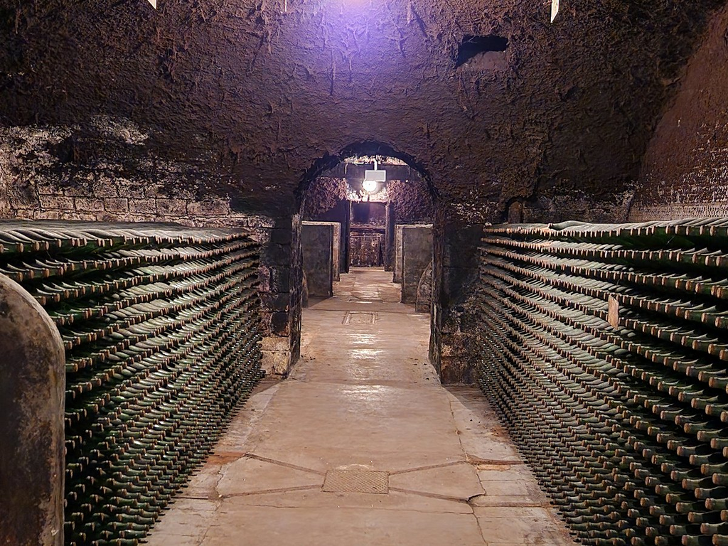

## Glück ist keine Strategie: Maersk & NotPetya

- Juni 2017: NotPetya – Wiper, getarnt als Ransomware, verbreitet über ukrainische Buchhaltungssoftware
- Maersk: Tausende Server, zehntausende PCs unbrauchbar, alle Domain Controller verschlüsselt – bis auf einen
- Der letzte stand in **Ghana** und war wegen eines Stromausfalls offline
- Wiederaufbau in rund zehn Tagen, Schaden mehrere hundert Mio. USD

[figure not shown]

## Adaptivität: Chaos Engineering

- Netflix „Chaos Monkey“ (ab 2011): fährt in Produktion zufällig Instanzen herunter
- Vorgehen: Hypothese → Experiment → Beobachten → Lernen
- Blast Radius klein halten, Abbruchkriterien festlegen
- **Game Days**: geplante Ausfallübungen mit dem ganzen Team

[figure not shown]

## Warum Prävention nicht reicht

- Zero-Days, Lieferketten, menschliche Fehler
- 100 % Prävention gibt es nicht.
- **Resilienz ist die letzte Verteidigungslinie.**

„Sicherheit schützt – Resilienz überlebt.“

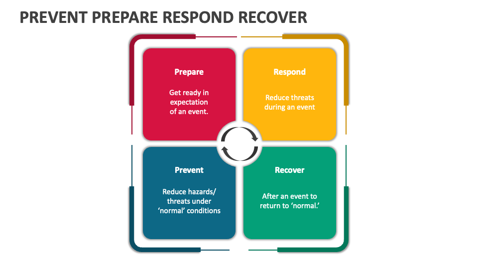

## Resilienz steht im Gesetz

**Standards & Frameworks**

- NIST SP 800-160 Vol. 2 Rev. 1 · ISO/IEC 27031:2025 · BSI-Standard 200-4 · ENISA-Leitfäden

**EU-Regulierung**

- NIS2 – Pflichten und Haftung der Leitung
- DORA – *Digital Operational **Resilience** Act* (seit Januar 2025)
- CER-Richtlinie – *Critical Entities **Resilience***
- Cyber **Resilience** Act – Produkte mit digitalen Elementen

[figure not shown]

## Relevanz für Cyber Security Management

- Resilienz ist ein Management- und Architekturthema.
- Standards liefern das Vorgehen, Regulierung macht Resilienz zur Leitungsaufgabe.
- Verbindung zu Incident Response, BCM und IT Service Continuity Management.

## Fallstudie: Ransomware in der Verwaltung

- **Anhalt-Bitterfeld (2021):** erster Cyber-Katastrophenfall Deutschlands, Bürgerdienste monatelang gestört
- **Südwestfalen-IT (2023):** ein kommunaler IT-Dienstleister, rund 70 Kommunen betroffen – Konzentrationsrisiko
- Entscheidend: offline verifizierte Backups, priorisierter Wiederanlauf nach BCM-Plan, Kommunikation

**Frage:** Welche Maßnahmen beschleunigen die Wiederherstellung?

[figure not shown]

## Fallstudie: DDoS auf einen Online-Service

- **Mirai / Dyn (Oktober 2016):** Botnetz aus IoT-Geräten (Kameras, Router) legt den DNS-Anbieter Dyn lahm – große Plattformen nicht erreichbar
- Maßnahmen: Anycast, CDN, WAF, elastische Kapazität
- DNS bei mehreren Anbietern = Diversität
- Transparente Statuskommunikation

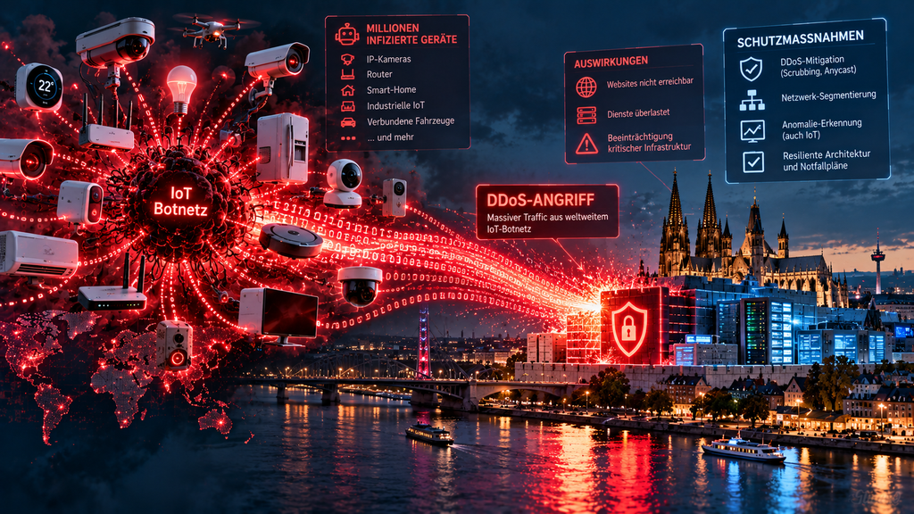

## Übung: Safety oder Security?

Gruppenaufgabe mit Szenarien: Cloud-Gaming, Krankenhaus-IT, Smart Home, Auto, Banking-App.

1. Risiken identifizieren
2. Safety vs. Security zuordnen
3. Resilienzmaßnahmen vorschlagen

5-Minuten-Kurzpräsentation pro Gruppe.

## Kernpunkte

- **„Sicherheit schützt – Resilienz überlebt.“** Prävention ist notwendig, aber nicht hinreichend.
- Safety und Security adressieren unterschiedliche Ursachen – Resilienz integriert beide.
- **Design for Failure:** Redundanz, Diversität, Wiederherstellbarkeit, Adaptivität.
- Resilienz braucht Technik, Prozesse und Menschen – und lebt von Übung und Lernen.

## Ausblick & Hausaufgabe

**Nächste Sitzung:** Modelle und Messbarkeit der Resilienz (RTO/RPO, MTTR, SLOs).

**Hausaufgabe:** Ein Beispiel recherchieren, das sich nach einer Störung besonders schnell erholte.

Kapitel zum Termin · Glossar · Quellen